# Imports

```python
import pandas as pd
import matplotlib.pyplot as plt
import seaborn as sns
import numpy as np
from pathlib import Path
import os

#imbalance-learn import
import imblearn as im

# sklearn imports
from sklearn.utils import _pprint as pp,resample
from sklearn.preprocessing import StandardScaler
from sklearn.pipeline import make_pipeline
from sklearn.model_selection import (
    train_test_split,
    cross_validate,
    GridSearchCV)
from sklearn.metrics import (
    fbeta_score,
    make_scorer,
    confusion_matrix,
    ConfusionMatrixDisplay)
from sklearn.linear_model import LogisticRegression
from sklearn.discriminant_analysis import LinearDiscriminantAnalysis
from sklearn.neighbors import KNeighborsClassifier
from sklearn.tree import DecisionTreeClassifier
from sklearn.svm import LinearSVC
from sklearn.ensemble import (
    RandomForestClassifier,
    HistGradientBoostingClassifier,
    AdaBoostClassifier)
from sklearn.neural_network import MLPClassifier

# scipy import
from scipy.stats import mannwhitneyu
```

```python
data = pd.read_csv('creditcard.csv')
```

```python
target = ['Class']
exclude_cols = ['Time']
```

# Exploratory Data Analysis

The dataset contains transaction made by European cardholders over a 2 day period in September 2013. The numerical input variables ranging from V1 to V28 are arrived at by PCA transformation.

```python
data.head()
```

|  | Time | V1 | V2 | V3 | V4 | V5 | V6 | V7 | V8 | V9 | ... | V21 | V22 | V23 | V24 | V25 | V26 | V27 | V28 | Amount | Class |
| --- | --- | --- | --- | --- | --- | --- | --- | --- | --- | --- | --- | --- | --- | --- | --- | --- | --- | --- | --- | --- | --- |
| 0 | 0.0 | -1.359807 | -0.072781 | 2.536347 | 1.378155 | -0.338321 | 0.462388 | 0.239599 | 0.098698 | 0.363787 | ... | -0.018307 | 0.277838 | -0.110474 | 0.066928 | 0.128539 | -0.189115 | 0.133558 | -0.021053 | 149.62 | 0 |
| 1 | 0.0 | 1.191857 | 0.266151 | 0.166480 | 0.448154 | 0.060018 | -0.082361 | -0.078803 | 0.085102 | -0.255425 | ... | -0.225775 | -0.638672 | 0.101288 | -0.339846 | 0.167170 | 0.125895 | -0.008983 | 0.014724 | 2.69 | 0 |
| 2 | 1.0 | -1.358354 | -1.340163 | 1.773209 | 0.379780 | -0.503198 | 1.800499 | 0.791461 | 0.247676 | -1.514654 | ... | 0.247998 | 0.771679 | 0.909412 | -0.689281 | -0.327642 | -0.139097 | -0.055353 | -0.059752 | 378.66 | 0 |
| 3 | 1.0 | -0.966272 | -0.185226 | 1.792993 | -0.863291 | -0.010309 | 1.247203 | 0.237609 | 0.377436 | -1.387024 | ... | -0.108300 | 0.005274 | -0.190321 | -1.175575 | 0.647376 | -0.221929 | 0.062723 | 0.061458 | 123.50 | 0 |
| 4 | 2.0 | -1.158233 | 0.877737 | 1.548718 | 0.403034 | -0.407193 | 0.095921 | 0.592941 | -0.270533 | 0.817739 | ... | -0.009431 | 0.798278 | -0.137458 | 0.141267 | -0.206010 | 0.502292 | 0.219422 | 0.215153 | 69.99 | 0 |

5 rows × 31 columns

There are no missing values

```python
data.info()
```

```
<class 'pandas.core.frame.DataFrame'>
RangeIndex: 284807 entries, 0 to 284806
Data columns (total 31 columns):
 #   Column  Non-Null Count   Dtype
---  ------  --------------   -----
 0   Time    284807 non-null  float64
 1   V1      284807 non-null  float64
 2   V2      284807 non-null  float64
 3   V3      284807 non-null  float64
 4   V4      284807 non-null  float64
 5   V5      284807 non-null  float64
 6   V6      284807 non-null  float64
 7   V7      284807 non-null  float64
 8   V8      284807 non-null  float64
 9   V9      284807 non-null  float64
```

[output cut: 23 more lines]

```python
with pd.option_context('display.float_format',lambda x: '%.2f' % x):
    display(data.describe())
```

|  | Time | V1 | V2 | V3 | V4 | V5 | V6 | V7 | V8 | V9 | ... | V21 | V22 | V23 | V24 | V25 | V26 | V27 | V28 | Amount | Class |
| --- | --- | --- | --- | --- | --- | --- | --- | --- | --- | --- | --- | --- | --- | --- | --- | --- | --- | --- | --- | --- | --- |
| count | 284807.00 | 284807.00 | 284807.00 | 284807.00 | 284807.00 | 284807.00 | 284807.00 | 284807.00 | 284807.00 | 284807.00 | ... | 284807.00 | 284807.00 | 284807.00 | 284807.00 | 284807.00 | 284807.00 | 284807.00 | 284807.00 | 284807.00 | 284807.00 |
| mean | 94813.86 | 0.00 | 0.00 | -0.00 | 0.00 | 0.00 | 0.00 | -0.00 | 0.00 | -0.00 | ... | 0.00 | -0.00 | 0.00 | 0.00 | 0.00 | 0.00 | -0.00 | -0.00 | 88.35 | 0.00 |
| std | 47488.15 | 1.96 | 1.65 | 1.52 | 1.42 | 1.38 | 1.33 | 1.24 | 1.19 | 1.10 | ... | 0.73 | 0.73 | 0.62 | 0.61 | 0.52 | 0.48 | 0.40 | 0.33 | 250.12 | 0.04 |
| min | 0.00 | -56.41 | -72.72 | -48.33 | -5.68 | -113.74 | -26.16 | -43.56 | -73.22 | -13.43 | ... | -34.83 | -10.93 | -44.81 | -2.84 | -10.30 | -2.60 | -22.57 | -15.43 | 0.00 | 0.00 |
| 25% | 54201.50 | -0.92 | -0.60 | -0.89 | -0.85 | -0.69 | -0.77 | -0.55 | -0.21 | -0.64 | ... | -0.23 | -0.54 | -0.16 | -0.35 | -0.32 | -0.33 | -0.07 | -0.05 | 5.60 | 0.00 |
| 50% | 84692.00 | 0.02 | 0.07 | 0.18 | -0.02 | -0.05 | -0.27 | 0.04 | 0.02 | -0.05 | ... | -0.03 | 0.01 | -0.01 | 0.04 | 0.02 | -0.05 | 0.00 | 0.01 | 22.00 | 0.00 |
| 75% | 139320.50 | 1.32 | 0.80 | 1.03 | 0.74 | 0.61 | 0.40 | 0.57 | 0.33 | 0.60 | ... | 0.19 | 0.53 | 0.15 | 0.44 | 0.35 | 0.24 | 0.09 | 0.08 | 77.16 | 0.00 |
| max | 172792.00 | 2.45 | 22.06 | 9.38 | 16.88 | 34.80 | 73.30 | 120.59 | 20.01 | 15.59 | ... | 27.20 | 10.50 | 22.53 | 4.58 | 7.52 | 3.52 | 31.61 | 33.85 | 25691.16 | 1.00 |

8 rows × 31 columns

Negative class (0) (Non-fraudulent transactions): 99.83%

Positive class (1) (Fraudulent transactions) : 0.17%

```python
data[target].value_counts(normalize=True)
```

```
Class
0        0.998273
1        0.001727
Name: proportion, dtype: float64
```

Over the period of data collection, from the total transacation value of $25,162,590, $60,128 was involved in fraudulent transactions, which amount to 0.24% of total transaction value.

```python
fraud_amount = data[data[target[0]] == 1]['Amount'].sum()
total_amount = data['Amount'].sum()
loss_ratio = fraud_amount / total_amount

fraud_amount, total_amount, loss_ratio
```

```
(60127.97, 25162590.009999998, 0.002389577939953885)
```

There is no need to check correlation because we already have these features from PCA

## Univariate plots

```python
def plot_univariate(data,columns,factor=5,**args):
    '''
    Makes a grid of axes which will be populated by kdeplots of `columns`
    The size of the grid is scaled by `factor`
    '''
    assert type(columns) is list

    n = len(columns)
    _, axs = plt.subplots(int(np.ceil(n/3)),3,figsize=[3 * factor,int(np.ceil(n/3) * factor)])

    for i,feature in enumerate(columns):
        sns.kdeplot(data,x=feature,ax=axs.flat[i],**args)

    plt.tight_layout()
```

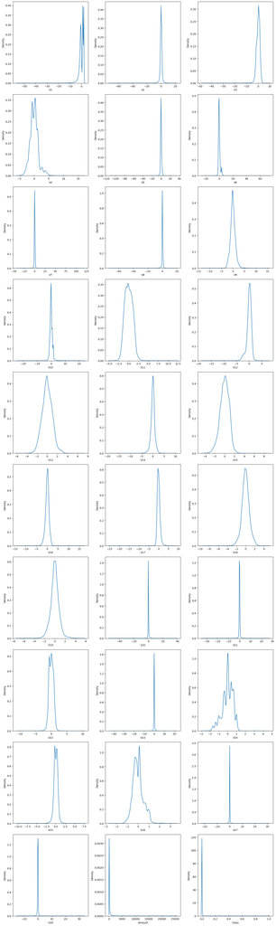

```python
desired_cols = [col for col in data.columns if col not in exclude_cols]
plot_univariate(data,desired_cols)
```

**Reason why scatterplots can be deceptive**. Using bivariate histogram instead.

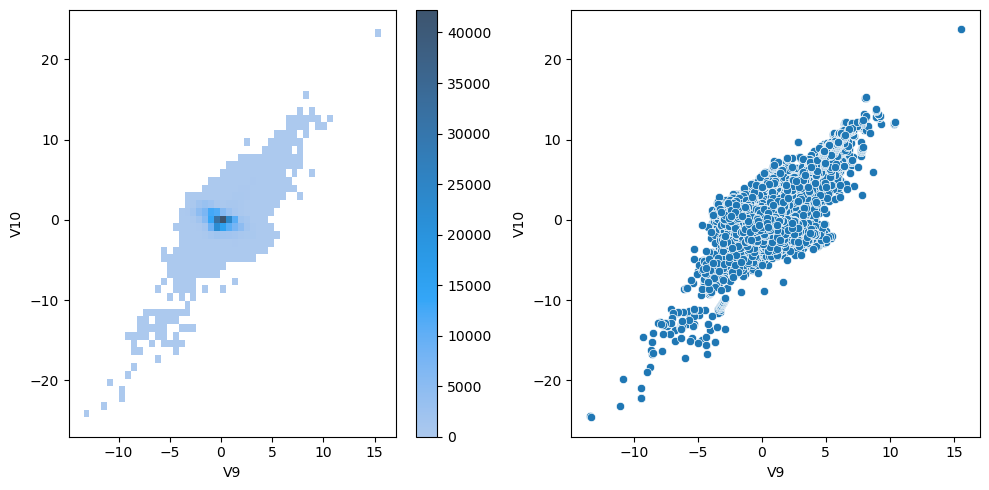

```python
_, axs = plt.subplots(1,2,figsize=[10,5])
sns.histplot(data,x='V9',y='V10',bins=50,cbar=True,ax=axs[0])
sns.scatterplot(data,x='V9',y='V10',ax=axs[1])
plt.tight_layout()
```

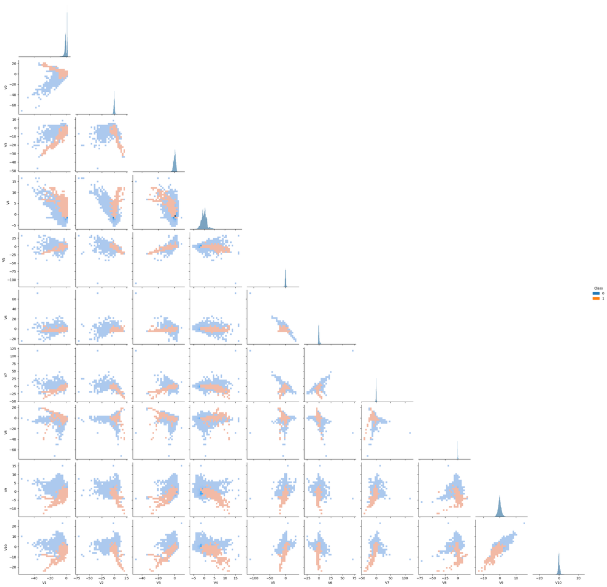

```python
sns.pairplot(data[['V1','V2','V3','V4','V5','V6','V7','V8','V9','V10','Class']],hue='Class',corner=True,kind='hist',plot_kws={'bins':30})
```

From a visual inspection of below graphs, V6, V13, V15, V22, V24, V25, V26 seem to have very similar density distribution across fraudulent and non-fraudulent cases.

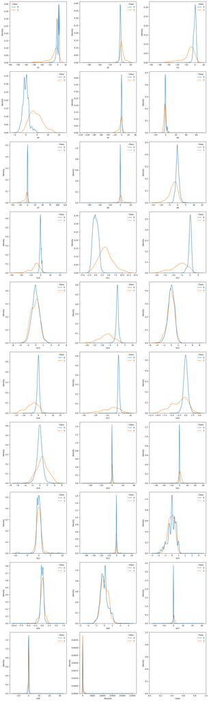

```python
plot_univariate(data,desired_cols,hue='Class',common_norm=False)
```

## Difference in means

There are features where mean seams quite different and some features where it is quite close

```python
data.groupby('Class').mean()
```

| Class | Time | V1 | V2 | V3 | V4 | V5 | V6 | V7 | V8 | V9 | ... | V20 | V21 | V22 | V23 | V24 | V25 | V26 | V27 | V28 | Amount |
| --- | --- | --- | --- | --- | --- | --- | --- | --- | --- | --- | --- | --- | --- | --- | --- | --- | --- | --- | --- | --- | --- |
| 0 | 94838.202258 | 0.008258 | -0.006271 | 0.012171 | -0.007860 | 0.005453 | 0.002419 | 0.009637 | -0.000987 | 0.004467 | ... | -0.000644 | -0.001235 | -0.000024 | 0.000070 | 0.000182 | -0.000072 | -0.000089 | -0.000295 | -0.000131 | 88.291022 |
| 1 | 80746.806911 | -4.771948 | 3.623778 | -7.033281 | 4.542029 | -3.151225 | -1.397737 | -5.568731 | 0.570636 | -2.581123 | ... | 0.372319 | 0.713588 | 0.014049 | -0.040308 | -0.105130 | 0.041449 | 0.051648 | 0.170575 | 0.075667 | 122.211321 |

2 rows × 30 columns

Mann Whitney U is a non-parametric test to whether two populations are identically distributed.

The test result is not significant on the below outputted columns. Hence, they are added to the list of excluded columns as they are unlikely to provide discriminating information.

```python
def multiple_mannwu(data,target,exclude=None,pvalue_thresh=0.01):
    '''
    Compares pvalue from `mannwhitneyu()` with a given threshold `pvalue_thresh`
    Returns columns in `data`, excludeept `target`, whose pvalue is above the threshold indicating
    that the null hypothesis (mean of the two sets in a column discriminated by `target` are equal) cannot
    be rejected.
    '''
    if type(exclude) is list:
        exclude = exclude + target
    elif exclude is None:
        exclude = target
    else:
        exclude = target + [exclude]

    d_col = [col for col in data.columns if col not in exclude]

    mask = data[target[0]] == 0

    nosig = []

    for col in d_col:
        x = data[mask][col]
        y = data[~mask][col]
        if mannwhitneyu(x,y).pvalue > pvalue_thresh:
            nosig.append(col)

    return nosig
```

```python
_features = multiple_mannwu(data,target,pvalue_thresh=0.05)
exclude = exclude_cols + _features
display(_features)
```

```
['V13', 'V15', 'V22']
```

# Modelling

Split the data 80:20 between train and test set in a stratified manner. The test set is set aside for final evaluation.

```python
train,test = train_test_split(data,test_size=0.2,stratify=data[target],random_state=9876)
```

```python
train.head()
```

|  | Time | V1 | V2 | V3 | V4 | V5 | V6 | V7 | V8 | V9 | ... | V21 | V22 | V23 | V24 | V25 | V26 | V27 | V28 | Amount | Class |
| --- | --- | --- | --- | --- | --- | --- | --- | --- | --- | --- | --- | --- | --- | --- | --- | --- | --- | --- | --- | --- | --- |
| 230184 | 146226.0 | 2.255889 | -1.505012 | -0.808560 | -1.668634 | -1.308710 | -0.195650 | -1.432749 | 0.093177 | -1.171014 | ... | -0.124897 | 0.060801 | 0.310999 | 0.647424 | -0.323789 | -0.222878 | 0.008770 | -0.054068 | 7.15 | 0 |
| 204689 | 135394.0 | 2.106139 | -0.798143 | -1.189310 | -0.720381 | -0.758720 | -0.553299 | -1.070078 | 0.075041 | -0.020218 | ... | 0.264418 | 0.778379 | 0.068968 | -0.521369 | -0.186387 | -0.078634 | 0.021085 | -0.027298 | 19.95 | 0 |
| 28599 | 35071.0 | -1.185866 | 1.226142 | 0.804271 | 0.958248 | -0.001800 | -0.885471 | 0.460888 | 0.078149 | -0.717416 | ... | 0.194333 | 0.600367 | 0.122303 | 0.425851 | -0.172097 | -0.357723 | -0.272225 | 0.069364 | 10.50 | 0 |
| 119959 | 75650.0 | -1.406713 | 1.493848 | 1.225097 | -1.349293 | 0.449902 | -0.655615 | 0.760328 | 0.305292 | -0.640502 | ... | -0.241368 | -0.860797 | -0.279210 | -0.452110 | 0.584831 | -0.094257 | -0.051081 | 0.036349 | 2.50 | 0 |
| 174824 | 122085.0 | -0.518872 | 0.323049 | -0.530168 | -0.989712 | 1.634748 | -0.437116 | 1.404158 | -0.431957 | 0.051537 | ... | 0.183203 | 0.837499 | -0.067642 | 0.198096 | -0.381740 | -0.747842 | -0.139885 | -0.003166 | 46.13 | 0 |

5 rows × 31 columns

The train set consists of 227,845 samples and test set consists of 56,962 samples.

```python
print('No. of train instances : ',train.shape[0])
print('No. of test instances : ', test.shape[0])
```

```
No. of train instances :  227845
No. of test instances :  56962
```

The distribution of classes in the train set is similar to the overall dataset.

```python
display(train[target].value_counts())
display(train[target].value_counts(normalize=True))
```

```
Class
0        227451
1           394
Name: count, dtype: int64
```

```
Class
0        0.998271
1        0.001729
Name: proportion, dtype: float64
```

```python
def get_xy(data,target,exclude=[],size=None):
    '''
    Splits `data` into X and y on the basis of `target` while excluding columns in `exclude`
    If `size` is provided as a float, returns a resampled subset of data.
    '''
    assert type(target) is list
    assert type(exclude) is list

    if size is not None and size > 0 and size < 1:
        data = resample(data,
                        replace=False,
                        n_samples=int(np.ceil(size*data.shape[0])),
                        stratify=data[target],
                        random_state=9876)

    return data[[col for col in data.columns if col not in [target[0],*exclude]]], data[target[0]]
```

```python
get_xy(train,target)[1].value_counts()
```

```
Class
0    227451
1       394
Name: count, dtype: int64
```

## Evaluation metric

**Evaluation Metrics** : Average Precision (discretized version of PR AUC) and F2 score

**Reason** : We need high recall in this situation in order to detect all truly fraudulent transactions. However, due to precision-recall tradeoff, a high recall will adversely impact precision. This would translate to poor user experience as many genuine transaction would be classified as fraudulent. So we need an evaluation metric that takes into consideration both precision and recall and that which focuses more on positive class.

F1 score and PR AUC are two such metrics. F1 will favour precision and recall having similar values, but there is no such consideration required in this scenario. We are vying for a higher recall. PR AUC will be a summary metric that will take into account all thresholds and resulting precision and recall. Instead of F1 score, we can use F2 score which will give more importance to recall over precision.

```python
f2 = make_scorer(fbeta_score,beta=2)
chosen_scoring = {'average precision': 'average_precision','f2':f2}
```

## Balancing

```python
oversampler = im.over_sampling.SMOTE(sampling_strategy=0.01,random_state=9876)
undersampler = im.under_sampling.RandomUnderSampler(sampling_strategy=0.02,random_state=9876)
```

The positive class has now increased ~2% of total instances.

```python
# steps = [('over',oversampler),('under',undersampler)]
# rebalance = im.pipeline.Pipeline(steps)
# rebalance.fit_resample(*get_xy(train,target,exclude_cols))[1].value_counts()
```

## Testing Models

```python
# Helper functions

def test_model(model,x,y,scoring,**args):
    '''
    Returns the results of cross validation of `model` on metrics `scoring` along with train_scores
    Additional named arguments to functions are passed through to `cross_validate()`
    '''
    assert type(scoring) is dict

    cv_scores = cross_validate(model,x,y,scoring=scoring,return_train_score=True,**args)

    return cv_scores

def summary(results,agg=False):
    '''
    Returns mean value of columns in `results`
    If `agg` is True, returns a dataframe collating various results in `results` passed as a dictionary
    '''
    if agg is True:
        assert type(results) is dict
        df = pd.DataFrame()
        for key in results.keys():
            df[key] = pd.DataFrame(pd.DataFrame(results[key]).mean(axis=0))
        return(df)
    else:
        return(pd.DataFrame(results).mean(axis=0))

def test_over_models(models,x,y,scoring,**args):
    '''
    Tests models passed as dictionary in `models` on data `x` and `y`
    '''
    assert type(models) is dict

    results = {}
    for key in models.keys():
        results[key] = test_model(models[key],x,y,scoring,**args)

    display(summary(results,agg=True))

def test_over_data(model,datas,scoring,**args):
    '''
    Tests model passed as `model` on different datasets passed as a list of lists in `datas`
    The elements of `datas` need to be formatted as ['name','x','y']
    '''
    results = {}
    assert type(datas) is list

    for data in datas:
        name = data[0]
        _x = data[1]
        _y = data[2]
        results[name] = test_model(model,_x,_y,scoring,**args)

    display(summary(results,agg=True))
```

This section is for individual testing of models.

```python
models = {
    'Logistic': make_pipeline(StandardScaler(),LogisticRegression()),
    'LDA': LinearDiscriminantAnalysis(),
    'KNN': KNeighborsClassifier(),
    'Tree': DecisionTreeClassifier(),
    'SVC': LinearSVC(),
    'RF': RandomForestClassifier(),
    'HGB': HistGradientBoostingClassifier(),
    'Ada': AdaBoostClassifier(),
    'MLP': MLPClassifier()
}

pipe_models = { key : im.pipeline.make_pipeline(oversampler,undersampler,models[key]) for key in models.keys() }
```

```python
train_x, train_y = get_xy(train,target,exclude_cols)
```

```python
results = {}
```

```python
results['Logistic'] = test_model(pipe_models['Logistic'],train_x,train_y,chosen_scoring)
summary(results['Logistic'])
```

```
fit_time                   0.379676
score_time                 0.025833
test_average precision     0.775992
train_average precision    0.783169
test_f2                    0.811099
train_f2                   0.816886
dtype: float64
```

```python
results['KNN'] = test_model(pipe_models['KNN'],train_x,train_y,chosen_scoring)
summary(results['KNN'])
```

```
fit_time                   0.117326
score_time                 7.054832
test_average precision     0.726229
train_average precision    0.920933
test_f2                    0.748187
train_f2                   0.893922
dtype: float64
```

```python
results['Tree'] = test_model(pipe_models['Tree'],train_x,train_y,chosen_scoring)
summary(results['Tree'])
```

```
fit_time                   4.390193
score_time                 0.014634
test_average precision     0.357940
train_average precision    0.633491
test_f2                    0.694900
train_f2                   0.896062
dtype: float64
```

```python
results['SVC'] = test_model(pipe_models['SVC'],train_x,train_y,chosen_scoring)
summary(results['SVC'])
```

```
fit_time                   0.578071
score_time                 0.030805
test_average precision     0.786126
train_average precision    0.788145
test_f2                    0.811447
train_f2                   0.816411
dtype: float64
```

```python
results['RF'] = test_model(pipe_models['RF'],train_x,train_y,chosen_scoring)
summary(results['RF'])
```

```
fit_time                   49.517888
score_time                  0.395611
test_average precision      0.851992
train_average precision     0.996217
test_f2                     0.842551
train_f2                    0.988834
dtype: float64
```

```python
results['HGB'] = test_model(pipe_models['HGB'],train_x,train_y,chosen_scoring)
summary(results['HGB'])
```

```
fit_time                   2.093622
score_time                 0.123978
test_average precision     0.852891
train_average precision    0.988732
test_f2                    0.838377
train_f2                   0.981290
dtype: float64
```

```python
results['Ada'] = test_model(pipe_models['Ada'],train_x,train_y,chosen_scoring)
summary(results['Ada'])
```

```
fit_time                   16.489126
score_time                  0.201321
test_average precision      0.759975
train_average precision     0.778394
test_f2                     0.760541
train_f2                    0.755231
dtype: float64
```

```python
results['MLP'] = test_model(pipe_models['MLP'],train_x,train_y,chosen_scoring)
summary(results['MLP'])
```

```
fit_time                   39.928020
score_time                  0.069507
test_average precision      0.808602
train_average precision     0.955041
test_f2                     0.799826
train_f2                    0.939518
dtype: float64
```

The best performing models with default configuration are tree based ensemble methods.

Histogram Gradient Boosting provides good performance with low train and inference times but both Histogram based Gradient Boosting and Random Forests are overfitting.

```python
summary(results,agg = True)
```

|  | Logistic | KNN | Tree | SVC | RF | HGB | Ada | MLP |
| --- | --- | --- | --- | --- | --- | --- | --- | --- |
| fit_time | 0.379676 | 0.117326 | 4.390193 | 0.578071 | 49.517888 | 2.093622 | 16.489126 | 39.928020 |
| score_time | 0.025833 | 7.054832 | 0.014634 | 0.030805 | 0.395611 | 0.123978 | 0.201321 | 0.069507 |
| test_average precision | 0.775992 | 0.726229 | 0.357940 | 0.786126 | 0.851992 | 0.852891 | 0.759975 | 0.808602 |
| train_average precision | 0.783169 | 0.920933 | 0.633491 | 0.788145 | 0.996217 | 0.988732 | 0.778394 | 0.955041 |
| test_f2 | 0.811099 | 0.748187 | 0.694900 | 0.811447 | 0.842551 | 0.838377 | 0.760541 | 0.799826 |
| train_f2 | 0.816886 | 0.893922 | 0.896062 | 0.816411 | 0.988834 | 0.981290 | 0.755231 | 0.939518 |

The following tests are performed on 10% of the original train set across different models.

```python
test_over_models(pipe_models,*get_xy(train,target,exclude_cols,size=0.1),chosen_scoring)
```

|  | Logistic | LDA | KNN | Tree | SVC | RF | HGB | Ada | MLP |
| --- | --- | --- | --- | --- | --- | --- | --- | --- | --- |
| fit_time | 0.034858 | 0.079543 | 0.016641 | 0.192856 | 0.081436 | 2.127398 | 1.545502 | 1.408812 | 5.634064 |
| score_time | 0.005146 | 0.009446 | 0.200080 | 0.004202 | 0.015375 | 0.026604 | 0.029841 | 0.028889 | 0.013227 |
| test_average precision | 0.764215 | 0.764178 | 0.616071 | 0.327894 | 0.754806 | 0.819435 | 0.811073 | 0.737595 | 0.787113 |
| train_average precision | 0.848495 | 0.752214 | 0.860910 | 0.589516 | 0.852941 | 0.968123 | 0.970338 | 0.901878 | 0.914766 |
| test_f2 | 0.759132 | 0.856624 | 0.693362 | 0.668273 | 0.777703 | 0.848291 | 0.831575 | 0.730343 | 0.824123 |
| train_f2 | 0.831018 | 0.833318 | 0.834748 | 0.871039 | 0.838366 | 0.975333 | 0.982594 | 0.884723 | 0.921345 |

The following tests a given model over different sizes of the dataset.

```python
ds_data = []
for size in np.arange(0.1,1,0.1):
    ds_data.append([str(size),*get_xy(train,target,exclude_cols,size=size)])
```

```python
test_over_data(pipe_models['HGB'],ds_data,chosen_scoring)
```

|  | 0.1 | 0.2 | 0.30000000000000004 | 0.4 | 0.5 | 0.6000000000000001 | 0.7000000000000001 | 0.8 | 0.9 |
| --- | --- | --- | --- | --- | --- | --- | --- | --- | --- |
| fit_time | 1.549482 | 1.220542 | 1.127654 | 1.317820 | 1.792807 | 1.663364 | 1.976792 | 2.203707 | 2.221403 |
| score_time | 0.029732 | 0.027938 | 0.030928 | 0.043338 | 0.067005 | 0.070172 | 0.098156 | 0.120267 | 0.136374 |
| test_average precision | 0.811073 | 0.838364 | 0.827606 | 0.837979 | 0.860979 | 0.830672 | 0.832617 | 0.835914 | 0.838150 |
| train_average precision | 0.970338 | 0.939075 | 0.979897 | 0.978999 | 0.991391 | 0.986564 | 0.983307 | 0.989744 | 0.983047 |
| test_f2 | 0.831575 | 0.816265 | 0.827197 | 0.836423 | 0.844497 | 0.839662 | 0.833661 | 0.831518 | 0.829214 |
| train_f2 | 0.982594 | 0.973856 | 0.975021 | 0.979435 | 0.981353 | 0.977319 | 0.971988 | 0.979300 | 0.974785 |

```python
test_over_data(pipe_models['RF'],ds_data,chosen_scoring)
```

|  | 0.1 | 0.2 | 0.30000000000000004 | 0.4 | 0.5 | 0.6000000000000001 | 0.7000000000000001 | 0.8 | 0.9 |
| --- | --- | --- | --- | --- | --- | --- | --- | --- | --- |
| fit_time | 2.147401 | 6.021093 | 11.053385 | 15.909114 | 21.025546 | 27.100481 | 31.314481 | 38.253374 | 44.598699 |
| score_time | 0.028112 | 0.055147 | 0.092112 | 0.134303 | 0.189957 | 0.211098 | 0.265522 | 0.315061 | 0.355359 |
| test_average precision | 0.813307 | 0.785515 | 0.808419 | 0.853890 | 0.836636 | 0.834036 | 0.826098 | 0.817533 | 0.830270 |
| train_average precision | 0.982358 | 0.980441 | 0.981132 | 0.991165 | 0.995313 | 0.991519 | 0.992421 | 0.988512 | 0.993725 |
| test_f2 | 0.852137 | 0.849467 | 0.858357 | 0.861843 | 0.849332 | 0.846081 | 0.843803 | 0.827664 | 0.831152 |
| train_f2 | 0.982628 | 0.983196 | 0.984989 | 0.986288 | 0.988220 | 0.981101 | 0.983069 | 0.990094 | 0.987086 |

# Hyperparameter Tuning

```python
def save_results(results,filename,folder="."):
    ''' Save the results to a given file and in a given folder
    '''
    folderpath = Path(folder)
    filepath = Path(folder,filename)

    os.makedirs(folderpath,exist_ok=True)

    results.to_csv(filepath)
```

For tuning purposes, 50% of the original train set is used in order to speed up training.

```python
tuning_x, tuning_y = get_xy(train,target,exclude_cols,size=0.5)
```

```python
tuning_y.value_counts()
```

```
Class
0    113726
1       197
Name: count, dtype: int64
```

## Histogram Based Gradient Boosting Classifier

```python
# hgb = im.pipeline.Pipeline([
#     ('smote',oversampler),
#     ('rus', undersampler),
#     ('hgb', HistGradientBoostingClassifier(scoring='average_precision'))
# ])
```

```python
# summary(test_model(hgb,tuning_x,tuning_y,scoring=chosen_scoring))
```

The major problem is overfitting of the model, so parameters are also tuned to calibrate mean_train_score

```python
# param_dist_hgb = [{
#               # 'smote__sampling_strategy': [samp_strat / 2],
#               # 'rus__sampling_strategy': [samp_strat],
#               'smotetomek__sampling_strategy': [samp_strat],
#               'hgb__max_bins': [50,100],
#               'hgb__max_depth': np.arange(2,5,1),
#               'hgb__learning_rate': [0.1,0.2],
#               # 'hgb__l2_regularization': [0,100,500,1000],
#               'hgb__max_features': [0.4,0.5,0.6],
#               # 'hgb__min_samples_leaf': np.arange(3000,8001,2000),
#               # 'hgb__max_iter' : [100,500,1000]
#             } for samp_strat in [0.02,0.05,0.1]]
# param_dist_hgb
```

```python
# gsc_hgb = GridSearchCV(hgb,param_dist_hgb,scoring='average_precision',cv=10,return_train_score=True,verbose=1).fit(tuning_x,tuning_y)
```

```python
# gsc_results_hgb = pd.DataFrame(rsc.cv_results_)

# with pd.option_context('display.max_colwidth',None,'display.max_row',None):
#     display(gsc_results_hgb.sort_values(by='rank_test_score')[['params','mean_test_score','std_test_score','mean_train_score','std_train_score']])
```

```python
# save_results(gsc_results_hgb,'maxbins,maxdepth,learningrate,maxfeatures,samplingstrategy',Path('results/hgb'))
```

```python
_ = im.pipeline.make_pipeline(oversampler,undersampler,HistGradientBoostingClassifier())
_.set_params(
              smote__sampling_strategy = 0.025,
              randomundersampler__sampling_strategy = 0.05,
              histgradientboostingclassifier__max_bins = 50,
              histgradientboostingclassifier__scoring = 'average_precision',
              histgradientboostingclassifier__max_depth =  2,
              histgradientboostingclassifier__learning_rate = 0.1,
              histgradientboostingclassifier__max_features = 0.4)

summary(test_model(_,train_x,train_y,scoring=chosen_scoring))
```

```
fit_time                   0.806242
score_time                 0.055328
test_average precision     0.797309
train_average precision    0.829837
test_f2                    0.798474
train_f2                   0.818594
dtype: float64
```

## Random Forest Classifier

```python
# rf = im.pipeline.Pipeline([
#     ('smote',oversampler),
#     ('rus', undersampler),
#     ('rf',RandomForestClassifier(n_estimators=10))
# ])
```

```python
# summary(test_model(rf,train_x,train_y,scoring=chosen_scoring))
```

```python
# summary(test_model(rf,tuning_x,tuning_y,scoring=chosen_scoring))
```

```python
# param_dist_rf = [{
#               'smote__sampling_strategy' : [samp_strat / 2],
#               'rus__sampling_strategy' : [samp_strat],
#               'rf__n_estimators': [100],
#               'rf__criterion': ['entropy'],
#               'rf__max_samples': np.arange(0.4,0.7,0.1),
#               'rf__bootstrap': [True],
#               'rf__max_leaf_nodes': [50,100,150],
#               'rf__max_features': [0.4,0.5,0.6],
#               # 'rf__min_samples_leaf': np.linspace(1,250,9,dtype=int),
#               # 'rf__min_samples_split': np.geomspace(2,10000,6,dtype=int),
#               'rf__max_depth' : [5,6,7]
#             } for samp_strat in [0.02,0.05,0.1]]

# param_dist_rf
```

```python
# gsc_rf = GridSearchCV(rf,param_dist_rf,scoring='average_precision',cv=5,return_train_score=True,verbose=1).fit(tuning_x,tuning_y)
```

```python
# gsc_results_rf = pd.DataFrame(gsc_rf.cv_results_)

# with pd.option_context('display.max_colwidth',None,'display.max_row',None):
#     display(
#         gsc_results_rf.sort_values(by='rank_test_score')
#         .query('param_rf__max_depth in [5,6,7]')[['params','mean_test_score','std_test_score','mean_train_score','std_train_score']]
#         )
```

```python
# save_results(gsc_results_rf,'maxdepth,maxfeatures,maxsamples,maxleafnodes,criterion,estimators,samplingstrategy',Path('results/rf'))
```

```python
_ = im.pipeline.make_pipeline(oversampler,undersampler,RandomForestClassifier())
_.set_params(
              randomforestclassifier__n_estimators = 100,
              randomforestclassifier__max_depth = 5,
              randomforestclassifier__criterion = 'entropy',
              randomforestclassifier__bootstrap = True,
              randomforestclassifier__max_samples = 0.5,
              randomforestclassifier__max_features = 0.5,
              randomforestclassifier__max_leaf_nodes = 100,
              smote__sampling_strategy = 0.01,
              randomundersampler__sampling_strategy = 0.02
            )

summary(test_model(_,train_x,train_y,scoring=chosen_scoring))
```

```
fit_time                   36.088854
score_time                  0.163479
test_average precision      0.837601
train_average precision     0.873818
test_f2                     0.831567
train_f2                    0.847607
dtype: float64
```

# Test set evaluation

```python
test_x,test_y = get_xy(test,target,exclude_cols)
```

Histogram Gradient Boosting is providing better results on the test set

## Histogram Based Gradient Boosting Classifier

```python
tuned_oversampler = im.over_sampling.SMOTE(sampling_strategy = 0.025,random_state=9876)
tuned_undersampler = im.under_sampling.RandomUnderSampler(sampling_strategy=0.05,random_state=9876)
tuned_hgb = HistGradientBoostingClassifier(max_bins = 50,
              scoring = 'average_precision',
              max_depth =  2,
              learning_rate = 0.1,
              max_features = 0.4,
              random_state=9876)

tuned_pipeline_hgb = im.pipeline.make_pipeline(tuned_oversampler,tuned_undersampler,tuned_hgb)
```

```python
tuned_pipeline_hgb.fit(train_x,train_y)
```

```
Pipeline(steps=[('smote', SMOTE(random_state=9876, sampling_strategy=0.025)),
                ('randomundersampler',
                 RandomUnderSampler(random_state=9876, sampling_strategy=0.05)),
                ('histgradientboostingclassifier',
                 HistGradientBoostingClassifier(max_bins=50, max_depth=2,
                                                max_features=0.4,
                                                random_state=9876,
                                                scoring='average_precision'))])
```

```python
pred_y = tuned_pipeline_hgb.predict(test_x)
```

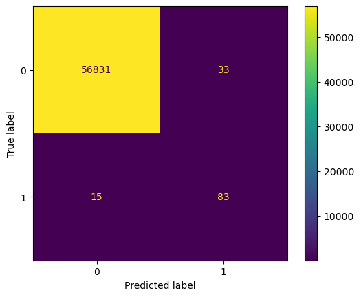

```python
ConfusionMatrixDisplay.from_predictions(test_y,pred_y);
```

```python
amount_fraud_total = test_x[test_y == 1]['Amount'].sum()
amount_fraud_identified = test_x[(pred_y==1) & (test_y == 1)]['Amount'].sum()

amount_save_ratio = amount_fraud_identified / amount_fraud_total

num_fraud_total = (test_y == 1).sum()
num_fraud_identified = ((test_y == 1) & (pred_y == 1)).sum()

num_save_ratio = num_fraud_identified / num_fraud_total

print(f'{num_save_ratio*100:.2f}% of fraudulent transaction were correctly identified leading to saving {amount_save_ratio * 100:.2f}% (€{amount_fraud_identified}) of value earlier lost to fraudulent transactions.')
```

```
84.69% of fraudulent transaction were correctly identified leading to saving 70.46% (€8593.05) of value earlier lost to fraudulent transactions.
```

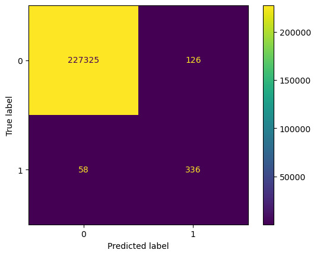

```python
pred_y_train = tuned_pipeline_hgb.predict(train_x)
ConfusionMatrixDisplay.from_predictions(train_y,pred_y_train);
```

## Random Forest Classifier

```python
tuned_oversampler = im.over_sampling.SMOTE(sampling_strategy = 0.01,random_state=9876)
tuned_undersampler = im.under_sampling.RandomUnderSampler(sampling_strategy=0.02,random_state=9876)
tuned_rf = RandomForestClassifier(n_estimators = 100,
              max_depth = 5,
              criterion = 'entropy',
              bootstrap = True,
              max_samples = 0.5,
              max_features = 0.5,
              max_leaf_nodes = 100,
              random_state=9876)

tuned_pipeline_rf = im.pipeline.make_pipeline(tuned_oversampler,tuned_undersampler,tuned_rf)
```

```python
tuned_pipeline_rf.fit(train_x,train_y)
```

```
Pipeline(steps=[('smote', SMOTE(random_state=9876, sampling_strategy=0.01)),
                ('randomundersampler',
                 RandomUnderSampler(random_state=9876, sampling_strategy=0.02)),
                ('randomforestclassifier',
                 RandomForestClassifier(criterion='entropy', max_depth=5,
                                        max_features=0.5, max_leaf_nodes=100,
                                        max_samples=0.5, random_state=9876))])
```

```python
pred_y = tuned_pipeline_rf.predict(test_x)
```

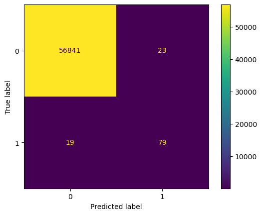

```python
ConfusionMatrixDisplay.from_predictions(test_y,pred_y);
```

```python
amount_fraud_total = test_x[test_y == 1]['Amount'].sum()
amount_fraud_identified = test_x[(pred_y==1) & (test_y == 1)]['Amount'].sum()

amount_save_ratio = amount_fraud_identified / amount_fraud_total

num_fraud_total = (test_y == 1).sum()
num_fraud_identified = ((test_y == 1) & (pred_y == 1)).sum()

num_save_ratio = num_fraud_identified / num_fraud_total

print(f'{num_save_ratio*100:.2f}% of fraudulent transaction were correctly identified leading to saving {amount_save_ratio * 100:.2f}% (€{amount_fraud_identified}) of value earlier lost to fraudulent transactions.')
```

```
80.61% of fraudulent transaction were correctly identified leading to saving 67.74% (€8261.48) of value earlier lost to fraudulent transactions.
```

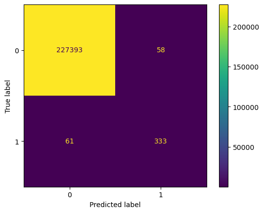

```python
pred_y_train = tuned_pipeline_rf.predict(train_x)
ConfusionMatrixDisplay.from_predictions(train_y,pred_y_train);
```